# Data Challenge competition - Football prediction

Attila Gulyás / Team Bella Vita

Note: - Data was provided by the organizer of the competition. It is found to be clean, no missing values, no duplicates. - There are 23 divisions and 10 seasons in the data.

| BASIC SETUP |
| --- |

```r
# empty memory
rm(list=ls())

# KOMMENT: install library if not exist -> megoldani majd

# Load libraries
library("tidyverse") # imap function for roc curve
library("data.table") # to use data in an efficient way
library("readxl") # to read xlsx data
library("caret") # to split data into train and holdput sets
library("dplyr") # to append commands easier
library("ROCR") # to evaluate model performance
library("h2o") # for autoML, java is kell hozzá
library("xgboost") # for extreme gradient boosting model
library("e1071") # for Naive Bayes
library("ranger") # for RF model
library("kernlab") # for SVM
library("mltools") # to calculate AUC manually
library("glmnet") # for GLMNET model
# library(ggplot2)
# library(ggthemes)
# library(grid)
# library(lattice)
# library(glmnet)
# library("skimr")
# library(gridExtra)

# Set the working directory
dir <-  "/Users/attilagulyas/Documents/GitHub/DataChallenge2023/"

#location folders
data_in <- paste0(dir,"01_raw/")
# func <- paste0(dir, "work/") - nem használt
output <- paste0(dir, "04_output/")
```

| LOAD DATA |
| --- |

```r
data <- as.data.table(read_excel(paste0(data_in, "competition_table.xlsx")))


# BASIC STISTICS
message(paste0("Döntetlen aránya: ", round(sum(data$draw_flag) / nrow(data), digits = 2)))
```

```
Döntetlen aránya: 0.26
```

```r
message(paste0("Hazai győzelem aránya: ", round(sum(data$home_win_flag) / nrow(data), digits = 2)))
```

```
Hazai győzelem aránya: 0.44
```

```r
message(paste0("Vendég győzelem aránya: ", round(sum(data$away_win_flag) / nrow(data), digits = 2)))
```

```
Vendég győzelem aránya: 0.3
```

| LABEL ENGINEERING |
| --- |

```r
data <- data %>%
  mutate(home_win_flag = factor(ifelse(home_win_flag == 0, "no", "yes"), levels = c("no", "yes")))

data <- data %>%
  mutate(away_win_flag = factor(ifelse(away_win_flag == 0, "no", "yes"), levels = c("no", "yes")))

data <- data %>%
  mutate(draw_flag = factor(ifelse(draw_flag == 0, "no", "yes"), levels = c("no", "yes")))
```

| FEATURE ENGINEERING |
| --- |

```r
# data structure
# str(data)
data <- data %>% mutate(
        # hazai csapat támadás erőssége előző meccsen
        home_goal_per_shot_roll1 = home_team_goal_roll1_sum / home_team_shot_roll1_sum,
        home_goal_per_shotontarget_roll1 = home_team_goal_roll1_sum / home_team_shot_on_target_roll1_sum,
        home_shotontarget_per_shots_roll1 = home_team_shot_on_target_roll1_sum / home_team_shot_roll1_sum,
        # hazai csapat támadás erőssége előző 4 meccsen
        home_goal_per_shot_roll4 = home_team_goal_roll4_sum / home_team_shot_roll4_sum,
        home_goal_per_shotontarget_roll4 = home_team_goal_roll4_sum / home_team_shot_on_target_roll4_sum,
        home_shotontarget_per_shots_roll4 = home_team_shot_on_target_roll4_sum / home_team_shot_roll4_sum,
        # vendég csapat támadás erőssége előző meccsen
        away_goal_per_shot_roll1 = away_team_goal_roll1_sum / away_team_shot_roll1_sum,
        away_goal_per_shotontarget_roll1 = away_team_goal_roll1_sum / away_team_shot_on_target_roll1_sum,
        away_shotontarget_per_shots_roll1 = away_team_shot_on_target_roll1_sum / away_team_shot_roll1_sum,
        # vendég csapat támadás erőssége előző 4 meccsen
        away_goal_per_shot_roll4 = away_team_goal_roll4_sum / away_team_shot_roll4_sum,
        away_goal_per_shotontarget_roll4 = away_team_goal_roll4_sum / away_team_shot_on_target_roll4_sum,
        away_shotontarget_per_shots_roll4 = away_team_shot_on_target_roll4_sum / away_team_shot_roll4_sum,

        # hazai csapat védekezés erőssége előző meccsen
        home_opponents_goal_per_shot_roll1 =
          home_team_opponents_goal_roll1_sum / home_team_opponents_shot_roll1_sum,
        home_opponents_goal_per_shotontarget_roll1 =
          home_team_opponents_goal_roll1_sum /     home_team_opponents_shot_on_target_roll1_sum,
        home_opponents_shotontarget_per_shots_roll1 =
          home_team_opponents_shot_on_target_roll1_sum / home_team_opponents_shot_roll1_sum,

        # hazai csapat védekezés erőssége előző 4 meccsen
        home_opponents_goal_per_shot_roll4 =
          home_team_opponents_goal_roll4_sum / home_team_opponents_shot_roll4_sum,
        home_opponents_goal_per_shotontarget_roll4 =
          home_team_opponents_goal_roll4_sum /     home_team_opponents_shot_on_target_roll4_sum,
        home_opponents_shotontarget_per_shots_roll4 =
          home_team_opponents_shot_on_target_roll4_sum / home_team_opponents_shot_roll4_sum,

        # vendég csapat védekezés erőssége előző meccsen
        away_opponents_goal_per_shot_roll1 =
          away_team_opponents_goal_roll1_sum / away_team_opponents_shot_roll1_sum,
        away_opponents_goal_per_shotontarget_roll1 =
          away_team_opponents_goal_roll1_sum /     away_team_opponents_shot_on_target_roll1_sum,
        away_opponents_shotontarget_per_shots_roll1 =
          away_team_opponents_shot_on_target_roll1_sum / away_team_opponents_shot_roll1_sum,

        # vendég csapat védekezés erőssége előző 4 meccsen
        away_opponents_goal_per_shot_roll4 =
          away_team_opponents_goal_roll4_sum / away_team_opponents_shot_roll4_sum,
        away_opponents_goal_per_shotontarget_roll4 =
          away_team_opponents_goal_roll4_sum /     away_team_opponents_shot_on_target_roll4_sum,
        away_opponents_shotontarget_per_shots_roll4 =
          away_team_opponents_shot_on_target_roll4_sum / away_team_opponents_shot_roll4_sum
)


# nullás osztás miatti hibás értékek javítása
data[,168:191] <- lapply(data[,168:191], function(x) {x[is.infinite(x)] <- 0; return(x)}) %>% as.data.table()
data[,168:191] <- lapply(data[,168:191], function(x) {x[is.na(x)] <- 0; return(x)}) %>% as.data.table()
```

| MODEL FOR PREDICTING HOME WIN |
| --- |

Create training set and holdout set samples

```r
set.seed(1990)

# smaller than usual training set so that models run faster - megj: 70% helyett 80%-ot használok
train_indices <- createDataPartition(data$home_win_flag, p = 0.8, list = FALSE)
data_train <- data[train_indices, ]

data_holdout <- data[-train_indices, ]

dim(data_train)
```

```
[1] 51333   167
```

```r
dim(data_holdout)
```

```
[1] 12833   167
```

Set evaluation rules Megj: 10-fold CV, repeated CV is megoldás lehet, kipróbálni

```r
train_control <- trainControl(
  method = "cv", #"repeatedcv",
  n = 10,
  classProbs = TRUE,
  summaryFunction = twoClassSummary  # necessary!
)

# MEGJ: repeated CV is egy megoldás

# Define the control parameters for the train function
# ctrl <- trainControl(method = "repeatedcv", number = 10, repeats = 3,
#                      classProbs = TRUE, summaryFunction = twoClassSummary)
```

Define variables

```r
# Basic numeric variables
basic_numeric_vars_set0 <- c(
  "odds_home_team_win",
  "odds_away_team_win"
)

basic_numeric_vars_set1 <- c(
  "odds_home_team_win",
  "odds_away_team_win",
  "odds_draw"
)

# glmnet (elastic net penalized) based selection
basic_numeric_vars_set2 <- c("odds_away_team_win",  # !
                             "odds_home_team_win",  # !
                             # "odds_draw", # humán input

                             "home_team_expected_point_roll4_sum",  # !
                              "away_team_expected_point_roll4_sum",  # !
                              "away_team_expected_point_roll3_sum",

                              "away_team_expected_point_mean",  # !
                              "home_team_expected_point_mean", # human input

                              "home_team_corner_roll4_sum", # ?  # !
                              "home_team_corner_roll3_sum", # ?
                              "home_team_corner_roll2_sum", # ?  # !
                              "away_team_opponents_corner_roll4_sum", # ?  # !
                             "away_team_opponents_corner_roll3_sum", # human input
                              "home_team_opponents_corner_roll2_sum", # ?

                              "home_team_shot_roll2_sum", # ?  # !
                              "away_team_opponents_shot_roll1_sum",  # ?  # !
                              "away_team_opponents_shot_roll4_sum", # ?  # !
                              "away_team_opponents_shot_roll3_sum", # ?  # !
                              "away_team_opponents_shot_roll2_sum", # human input

                              "away_team_opponents_shot_on_target_roll4_sum" # !

                             )


# xgb based selection
basic_numeric_vars_set3 <- c("odds_away_team_win", # !
                             "odds_home_team_win", # !
                             "odds_draw", # !

                             "odds_home_team_defeat_roll4_mean", # !
                             "odds_home_team_defeat_roll3_mean", # human input
                             "odds_home_team_defeat_roll2_mean",

                             "odds_away_team_defeat_roll4_mean",
                             "odds_away_team_defeat_roll3_mean", # # ! human input
                             "odds_away_team_defeat_roll2_mean", # human input

                             "odds_away_team_win_roll4_mean", # !
                             "odds_away_team_win_roll3_mean",

                             "odds_home_team_win_roll4_mean", # human input
                             "odds_home_team_win_roll3_mean",

                              "odds_home_team_draw_roll4_mean",
                             "odds_home_team_draw_roll3_mean", # human input
                             "odds_away_team_draw_roll4_mean", # human input
                             "odds_away_team_draw_roll3_mean",

                              "away_team_expected_point_mean", # !
                             "home_team_expected_point_mean", # human input
                              "home_team_corner_roll3_sum", # ?
                              "away_team_corner_roll2_sum", # ?
                              "away_team_opponents_corner_roll4_sum", # ?

                             "home_team_shot_roll2_sum", # ?
                             "home_team_shot_roll4_sum", # ?
                             "home_shotontarget_per_shots_roll4",
                             "away_team_opponents_shot_roll4_sum", # ?
                             "away_team_opponents_shot_on_target_roll3_sum"

                             )


# random forest based selection
basic_numeric_vars_set4 <- c("odds_away_team_win",
                             "odds_home_team_win",
                             "odds_draw",

                             "odds_home_team_defeat_roll4_mean",
                             "odds_home_team_defeat_roll3_mean",
                             "odds_home_team_defeat_roll2_mean",
                             "odds_home_team_defeat_roll1_mean", # human input

                             "odds_away_team_defeat_roll4_mean",
                             "odds_away_team_defeat_roll3_mean",
                             "odds_away_team_defeat_roll2_mean",
                             "odds_away_team_defeat_roll1_mean", # human input

                             "odds_home_team_win_roll4_mean",
                             "odds_home_team_win_roll3_mean",
                             "odds_home_team_win_roll2_mean",
                             "odds_home_team_win_roll1_mean",

                             "odds_away_team_win_roll4_mean",
                             "odds_away_team_win_roll3_mean",
                             "odds_away_team_win_roll2_mean",
                             "odds_away_team_win_roll1_mean",

                             "odds_away_team_draw_roll4_mean",

                             "home_team_expected_point_roll4_sum",
                             "away_team_expected_point_roll4_sum",  # human input
                             "away_team_expected_point_mean",
                             "home_team_expected_point_mean"
                             )

# best variables in logistic regression
basic_numeric_vars_set5 <- c("odds_home_team_win", "odds_away_team_win", "home_team_expected_point_roll4_sum", "away_team_opponents_shot_roll1_sum", "away_team_expected_point_mean", "away_team_opponents_corner_roll4_sum")

# Log variables
# Higher order variables
# Factorized variables
# Dummy variables
```

Define predictor sets

```r
# basic two odds
predictors_0 <- c(basic_numeric_vars_set0)

# basic three odds
predictors_1 <- c(basic_numeric_vars_set1)

# all variables
predictors_2 <- colnames(data[,-c("home_win_flag", "draw_flag", "away_win_flag", "match_id")])

# glmnet (elastic net penalized) based selection
predictors_3 <- c(basic_numeric_vars_set2)

# xgb based selection
predictors_4 <- c(basic_numeric_vars_set3)

# random forest based selection
predictors_5 <- c(basic_numeric_vars_set4)

# best variables in logistic regression
predictors_6 <- c(basic_numeric_vars_set5)
```

| MODELLEK: |
| --- |

## Logistic regression v1 - NO transformation

```r
#  train the model
set.seed(857)

# glmnet (elastic net penalized) based selection is the best
glm_model1 <- train(home_win_flag ~ .,
                   data = data_train[ ,colnames(data_train) %in% c("home_win_flag", predictors_0), with=FALSE],
                   method = "glm",
                   trControl = train_control)
```

```r
# model summary
# summary(glm_model1)
```

```r
# AUC on validation set
auc_cv <- glm_model1[["results"]][["ROC"]]
message(paste0("AUC from CV: ", round(auc_cv, digits = 4)))
```

```
AUC from CV: 0.6813
```

```r
 # 0.6813

sensitivity_cv <- glm_model1[["results"]][["Sens"]]
message(paste0("Sensitivity from CV: ", round(sensitivity_cv, digits = 4)))
```

```
Sensitivity from CV: 0.819
```

```r
# 0.819
```

```r
# variable importance
varimp <- varImp(glm_model)
plot(varImp(glm_model))
```

## Logistic regression v2 - NO transformation - with div differentiation

```r
#  train the model
set.seed(857)

# glmnet (elastic net penalized) based selection is the best
glm_model2 <- train(home_win_flag ~ odds_home_team_win * div,
                   data = data_train[ ,colnames(data_train) %in% c("home_win_flag", predictors_1, "div"), with=FALSE],
                   method = "glm",
                   trControl = train_control)
```

```r
# AUC on validation set
auc_cv <- glm_model2[["results"]][["ROC"]]
message(paste0("AUC from CV: ", round(auc_cv, digits = 4)))
```

```
AUC from CV: 0.6779
```

```r
 # 0.6779

sensitivity_cv <- glm_model2[["results"]][["Sens"]]
message(paste0("Sensitivity from CV: ", round(sensitivity_cv, digits = 4)))
```

```
Sensitivity from CV: 0.7195
```

```r
# 0.7195
```

Rosszabb mnint a div nélküli.

LOG NA lekezelése: kicsi számot hozzáadni Logistic regression v3 - Log transformation - differentiate by div ————————————–

```r
#  train the model
set.seed(857)

# glmnet (elastic net penalized) based selection is the best
glm_model3 <- train(home_win_flag ~ log(odds_home_team_win ) * div + log(odds_away_team_win + 0.001) * div + log(odds_draw + 0.001) * div,
                   data = data_train[ ,colnames(data_train) %in% c("home_win_flag", predictors_1, "div"), with=FALSE],
                   method = "glm",
                   trControl = train_control)
```

```r
# AUC on validation set
auc_cv <- glm_model3[["results"]][["ROC"]]
message(paste0("AUC from CV: ", round(auc_cv, digits = 4)))
```

```
AUC from CV: 0.6804
```

```r
 # 0.6804

sensitivity_cv <- glm_model3[["results"]][["Sens"]]
message(paste0("Sensitivity from CV: ", round(sensitivity_cv, digits = 4)))
```

```
Sensitivity from CV: 0.7843
```

```r
# 0.7843
```

Picit rosszabb mint az sima modell. Egész jó.

LOG NA lekezelése: kicsi számot hozzáadni Logistic regression v4 - Log transformation - NO differentiate by div ————————————–

```r
#  train the model
set.seed(857)

# glmnet (elastic net penalized) based selection is the best
glm_model4 <- train(home_win_flag ~ log(odds_home_team_win + 0.001) + log(odds_away_team_win + 0.001) + log(odds_draw + 0.001),
                   data = data_train[ ,colnames(data_train) %in% c("home_win_flag", predictors_1), with=FALSE],
                   method = "glm",
                   trControl = train_control)
```

```r
# AUC on validation set
auc_cv <- glm_model4[["results"]][["ROC"]]
message(paste0("AUC from CV: ", round(auc_cv, digits = 4)))
```

[output not shown]

```r
 # 0.6817

sensitivity_cv <- glm_model4[["results"]][["Sens"]]
message(paste0("Sensitivity from CV: ", round(sensitivity_cv, digits = 4)))
```

[output not shown]

```r
# 0.7915
```

## Logistic regression v5 - Probability transformation - NO differentiate by div

Calculate probabilities

```r
data_train[,odds_home_team_win_p := 1/(1+odds_home_team_win)]
data_train[,odds_away_team_win_p := 1/(1+odds_away_team_win)]
data_train[,odds_draw_p := 1/(1+odds_draw)]
```

```r
#  train the model
set.seed(857)

# glmnet (elastic net penalized) based selection is the best
glm_model5 <- train(home_win_flag ~ odds_home_team_win_p + odds_away_team_win_p + odds_draw_p,
                   data = data_train[ ,colnames(data_train) %in% c("home_win_flag", "odds_home_team_win_p", "odds_away_team_win_p", "odds_draw_p"), with=FALSE],
                   method = "glm",
                   trControl = train_control)
```

```r
# AUC on validation set
auc_cv <- glm_model5[["results"]][["ROC"]]
message(paste0("AUC from CV: ", round(auc_cv, digits = 4)))
```

```
AUC from CV: 0.6817
```

```r
 # 0.6817

sensitivity_cv <- glm_model5[["results"]][["Sens"]]
message(paste0("Sensitivity from CV: ", round(sensitivity_cv, digits = 4)))
```

```
Sensitivity from CV: 0.774
```

```r
# 0.774
```

Eddig a legjobb modell.

## Logistic regression v6 - Probability transformation - with differentiation by div

Calculate probabilities

```r
data_train[,odds_home_team_win_p := 1/(1+odds_home_team_win)]
data_train[,odds_away_team_win_p := 1/(1+odds_away_team_win)]
data_train[,odds_draw_p := 1/(1+odds_draw)]
```

```r
#  train the model
set.seed(857)

# glmnet (elastic net penalized) based selection is the best
glm_model6 <- train(home_win_flag ~ odds_home_team_win_p * div + odds_away_team_win_p * div + odds_draw_p * div,
                   data = data_train[ ,colnames(data_train) %in% c("home_win_flag", "odds_home_team_win_p", "odds_away_team_win_p", "odds_draw_p", "div"), with=FALSE],
                   method = "glm",
                   trControl = train_control)
```

```r
# AUC on validation set
auc_cv <- glm_model6[["results"]][["ROC"]]
message(paste0("AUC from CV: ", round(auc_cv, digits = 4)))
```

```
AUC from CV: 0.6803
```

```r
 # 0.6803

sensitivity_cv <- glm_model6[["results"]][["Sens"]]
message(paste0("Sensitivity from CV: ", round(sensitivity_cv, digits = 4)))
```

```
Sensitivity from CV: 0.7764
```

```r
# 0.774
```

GYengébb mint div-vel.

## Logistic regression v7 - z-score transformation - with NO differentiation by div

Calculate z-scores

```r
# data_train$odds_home_team_win_z <- 0
#
# for(i in 1:nrow(data_train)){
#   s_div <- data_train[i,]$div
#
#   mean_odds_home_team_win <- mean(data_train[div == s_div,]$odds_home_team_win)
#   sd_odds_home_team_win <- sd(data_train[div == s_div,]$odds_home_team_win, na.rm = T)
#
# data_train[i,"odds_home_team_win_z"] <- (data_train[i,"odds_home_team_win"] - mean_odds_home_team_win) / sd_odds_home_team_win
#
# }


mean_odds_home_team_win <- mean(data_train$odds_home_team_win)
sd_odds_home_team_win <- sd(data_train$odds_home_team_win)
data_train$odds_home_team_win_z <-  - (data_train$odds_home_team_win - mean_odds_home_team_win) / sd_odds_home_team_win

mean_odds_away_team_win <- mean(data_train$odds_away_team_win)
sd_odds_away_team_win <- sd(data_train$odds_away_team_win)
data_train$odds_away_team_win_z <-  - (data_train$odds_away_team_win - mean_odds_away_team_win) / sd_odds_away_team_win


mean_odds_draw <- mean(data_train$odds_draw)
sd_odds_draw <- sd(data_train$odds_draw)
data_train$odds_draw_z <-  - (data_train$odds_draw - mean_odds_draw) / sd_odds_draw
```

```r
#  train the model
set.seed(857)

# glmnet (elastic net penalized) based selection is the best
glm_model7 <- train(home_win_flag ~ odds_home_team_win_z + odds_away_team_win_z + odds_draw_z,
                   data = data_train[ ,colnames(data_train) %in% c("home_win_flag", "odds_home_team_win_z", "odds_away_team_win_z", "odds_draw_z"), with=FALSE],
                   method = "glm",
                   trControl = train_control)
```

```r
# AUC on validation set
auc_cv <- glm_model7[["results"]][["ROC"]]
message(paste0("AUC from CV: ", round(auc_cv, digits = 4)))
```

```
AUC from CV: 0.6817
```

```r
 # 0.6817

sensitivity_cv <- glm_model7[["results"]][["Sens"]]
message(paste0("Sensitivity from CV: ", round(sensitivity_cv, digits = 4)))
```

```
Sensitivity from CV: 0.8174
```

```r
# 0.8174
```

[output not shown]

Logistic regression - v1

```r
# AUC on holdout set
predicted_glm1_holdout <- predict(glm_model1,
                                 newdata = data_holdout,
                                 type = "prob")[["yes"]]


prediction_holdout_glm1 <- prediction(predicted_glm1_holdout, data_holdout$home_win_flag)
auc_holdout_glm1 <- performance(prediction_holdout_glm1, measure = "auc")@y.values[[1]]
message(paste0("AUC on holdout set for GLM1: ", round(auc_holdout_glm1, digits = 4)))
```

```
AUC on holdout set for GLM1: 0.6781
```

Logistic regression - v2

```r
# AUC on holdout set
predicted_glm2_holdout <- predict(glm_model2,
                                 newdata = data_holdout,
                                 type = "prob")[["yes"]]


prediction_holdout_glm2 <- prediction(predicted_glm2_holdout, data_holdout$home_win_flag)
auc_holdout_glm2 <- performance(prediction_holdout_glm2, measure = "auc")@y.values[[1]]
message(paste0("AUC on holdout set for GLM2: ", round(auc_holdout_glm2, digits = 4)))
```

```
AUC on holdout set for GLM2: 0.6757
```

Logistic regression - v3 ERROR???

```r
# AUC on holdout set
predicted_glm3_holdout <- predict(glm_model3,
                                 newdata = data_holdout,
                                 type = "prob")[["yes"]]


prediction_holdout_glm3 <- prediction(predicted_glm3_holdout, data_holdout$home_win_flag)
```

```
Error: 'predictions' contains NA.
```

Logistic regression - v4

```r
# AUC on holdout set
predicted_glm4_holdout <- predict(glm_model4,
                                 newdata = data_holdout,
                                 type = "prob")[["yes"]]


prediction_holdout_glm4 <- prediction(predicted_glm4_holdout, data_holdout$home_win_flag)
auc_holdout_glm4 <- performance(prediction_holdout_glm4, measure = "auc")@y.values[[1]]
message(paste0("AUC on holdout set for GLM4: ", round(auc_holdout_glm4, digits = 4)))
```

```
AUC on holdout set for GLM4: 0.6784
```

Logistic regression - v5

```r
data_holdout[,odds_home_team_win_p := 1/(1+odds_home_team_win)]
data_holdout[,odds_away_team_win_p := 1/(1+odds_away_team_win)]
data_holdout[,odds_draw_p := 1/(1+odds_draw)]

# AUC on holdout set
predicted_glm5_holdout <- predict(glm_model5,
                                 newdata = data_holdout,
                                 type = "prob")[["yes"]]


prediction_holdout_glm5 <- prediction(predicted_glm5_holdout, data_holdout$home_win_flag)
auc_holdout_glm5 <- performance(prediction_holdout_glm5, measure = "auc")@y.values[[1]]
message(paste0("AUC on holdout set for GLM5: ", round(auc_holdout_glm5, digits = 4)))
```

```
AUC on holdout set for GLM5: 0.6784
```

Logistic regression - v6

```r
data_holdout[,odds_home_team_win_p := 1/(1+odds_home_team_win)]
data_holdout[,odds_away_team_win_p := 1/(1+odds_away_team_win)]
data_holdout[,odds_draw_p := 1/(1+odds_draw)]

# AUC on holdout set
predicted_glm6_holdout <- predict(glm_model6,
                                 newdata = data_holdout,
                                 type = "prob")[["yes"]]


prediction_holdout_glm6 <- prediction(predicted_glm6_holdout, data_holdout$home_win_flag)
auc_holdout_glm6 <- performance(prediction_holdout_glm6, measure = "auc")@y.values[[1]]
message(paste0("AUC on holdout set for GLM5: ", round(auc_holdout_glm6, digits = 4)))
```

```
AUC on holdout set for GLM5: 0.6777
```

Logistic regression - v7

```r
mean_odds_home_team_win <- mean(data_holdout$odds_home_team_win)
sd_odds_home_team_win <- sd(data_holdout$odds_home_team_win)
data_holdout$odds_home_team_win_z <-  - (data_holdout$odds_home_team_win - mean_odds_home_team_win) / sd_odds_home_team_win

mean_odds_away_team_win <- mean(data_holdout$odds_away_team_win)
sd_odds_away_team_win <- sd(data_holdout$odds_away_team_win)
data_holdout$odds_away_team_win_z <-  - (data_holdout$odds_away_team_win - mean_odds_away_team_win) / sd_odds_away_team_win


mean_odds_draw <- mean(data_holdout$odds_draw)
sd_odds_draw <- sd(data_holdout$odds_draw)
data_holdout$odds_draw_z <-  - (data_holdout$odds_draw - mean_odds_draw) / sd_odds_draw



# AUC on holdout set
predicted_glm7_holdout <- predict(glm_model7,
                                 newdata = data_holdout,
                                 type = "prob")[["yes"]]


prediction_holdout_glm7 <- prediction(predicted_glm7_holdout, data_holdout$home_win_flag)
auc_holdout_glm7 <- performance(prediction_holdout_glm7, measure = "auc")@y.values[[1]]
message(paste0("AUC on holdout set for GLM7: ", round(auc_holdout_glm7, digits = 4)))
```

```
AUC on holdout set for GLM7: 0.6782
```

COLLECT PREDICTIONS INTO A OUTPUT TABLE

```r
predcition_lists <-c("GLM1" = prediction_holdout_glm1@predictions,
                     "GLM2" = prediction_holdout_glm2@predictions,
                     # "GLM3" = prediction_holdout_glm3@predictions,
                     "GLM4" = prediction_holdout_glm4@predictions,
                     "GLM5" = prediction_holdout_glm5@predictions,
                     "GLM6" = prediction_holdout_glm6@predictions,
                     "GLM7" = prediction_holdout_glm7@predictions)
prediction_table <-data.table(do.call(cbind, predcition_lists))

# ensembled : model average
prediction_table$ensemble1 = (prediction_table$GLM4 + prediction_table$GLM5) / 2
prediction_table$ensemble2 = (prediction_table$GLM4 + prediction_table$GLM5 + prediction_table$GLM1) / 3

# Results - fact
prediction_table$actual <- data_holdout$home_win_flag
```

```r
# Calculate AUC manually

auc_holdout_ensemble1<- auc_roc(preds = prediction_table$ensemble1, actuals = ordered(prediction_table$actual))
auc_holdout_ensemble2<- auc_roc(preds = prediction_table$ensemble2, actuals = ordered(prediction_table$actual))


message(paste0("AUC on holdout set for ensemble1 Model: ", round(auc_holdout_ensemble1, digits = 4)))
```

```
AUC on holdout set for ensemble1 Model: 0.6784
```

```r
message(paste0("AUC on holdout set for ensemble2 Model: ", round(auc_holdout_ensemble2, digits = 4)))
```

```
AUC on holdout set for ensemble2 Model: 0.6784
```

ROC curve on the TEST set

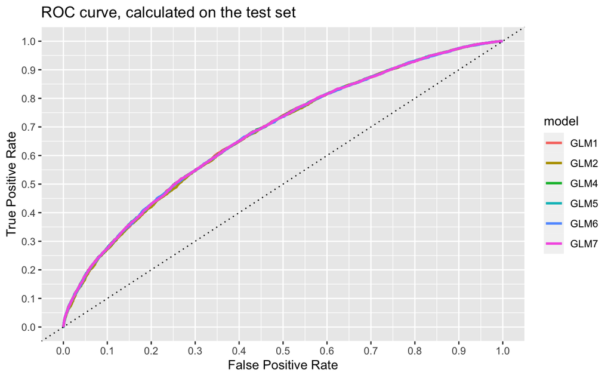

```r
roc_df_logit_rf <- imap(list("GLM1" = glm_model1,
"GLM2" = glm_model2,
# "GLM3" = glm_model3,
"GLM4" = glm_model4,
"GLM5" = glm_model5,
"GLM6" = glm_model6,
"GLM7" = glm_model7
 ), ~ {
  model <- .x
  predicted_probabilities <- predict(model, newdata = data_holdout, type = "prob")
  rocr_prediction <- prediction(predicted_probabilities[["yes"]], data_holdout[["home_win_flag"]])

  tpr_fpr_performance <- performance(rocr_prediction, "tpr", "fpr")
  tibble(
    model = .y,
    FPR = tpr_fpr_performance@x.values[[1]],
    TPR = tpr_fpr_performance@y.values[[1]],
    cutoff = tpr_fpr_performance@alpha.values[[1]]
  )
}) %>% bind_rows()

ggplot(roc_df_logit_rf) +
  geom_line(aes(FPR, TPR, color = model), size = 1) +
  geom_abline(intercept = 0, slope = 1,  linetype = "dotted", col = "black") +
  scale_y_continuous(limits = c(0, 1), breaks = seq(0, 1, .1)) +
  scale_x_continuous(limits = c(0, 1), breaks = seq(0, 1, .1)) +
  xlab("False Positive Rate") + ylab("True Positive Rate") +
  ggtitle("ROC curve, calculated on the test set")
```

| SAVE MODELS |
| --- |

```r
saveRDS(rf_model, paste0(output,"home_model_rf.rda"))
saveRDS(glm_model, paste0(output,"home_model_glm.rda"))
saveRDS(bayesglm_model, paste0(output,"home_model_bayesglm.rda"))
saveRDS(glmnet_model, paste0(output,"home_model_glmnet.rda"))
saveRDS(gbm_model, paste0(output,"home_model_gbm.rda"))
saveRDS(xgb_model, paste0(output,"home_model_xgb.rda"))
saveRDS(nb_model, paste0(output,"home_model_nb.rda"))
saveRDS(knn_model, paste0(output,"home_model_knn.rda"))
saveRDS(svm_model, paste0(output,"home_model_svm.rda"))
```

LOAD MODELS

```r
rf_model <- readRDS(paste0(output,"home_model_rf.rda"))
glm_model <- readRDS(paste0(output,"home_model_glm.rda"))
gbm_model <- readRDS(paste0(output,"home_model_gbm.rda"))
xgb_model <- readRDS(paste0(output,"home_model_xgb.rda"))
nb_model <- readRDS(paste0(output,"home_model_nb.rda"))
knn_model <- readRDS(paste0(output,"home_model_knn.rda"))
svm_model <- readRDS(paste0(output,"home_model_svm.rda"))
```

| CALIBRATION TEST |
| --- |

1. CALIBRATION TEST - Logistic Regression v1

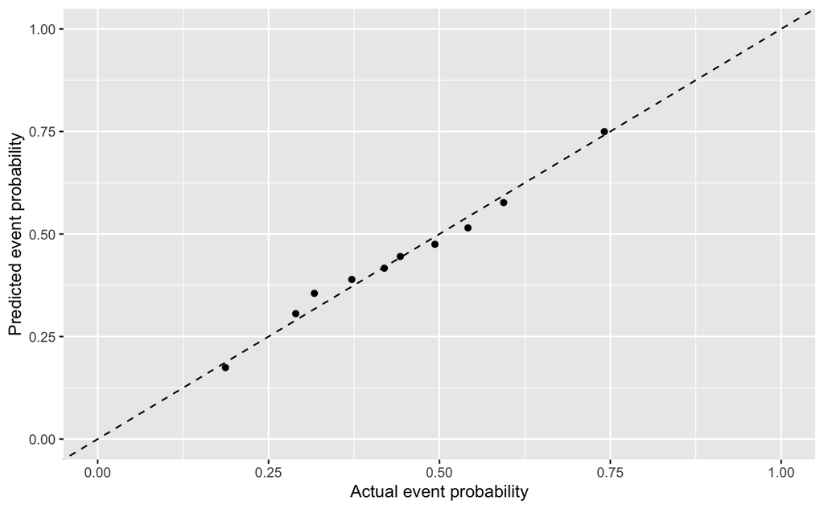

```r
# calibration plot: how well do estimated vs actual event probabilities relate to each other?
# -------------------------------------------------
actual_vs_predicted_glm<- data.frame(
  actual = ifelse(data_holdout[["home_win_flag"]] == "yes", 1, 0),
  predicted = predicted_glm1_holdout
)

# order observations accordingly

num_groups <- 10

calibration_logit <- actual_vs_predicted_glm %>%
  # ntile: assign group ids based on a variable. similar to "cut".
  mutate(predicted_score_group = ntile(predicted, num_groups)) %>%
  group_by(predicted_score_group) %>%
  summarise(mean_actual = mean(actual), mean_predicted = mean(predicted), num_obs = n())

ggplot(calibration_logit,aes(x = mean_actual, y = mean_predicted)) +
  geom_point() +
  geom_abline(intercept = 0, slope = 1, linetype = "dashed") +
  labs(x = "Actual event probability", y = "Predicted event probability") +
  ylim(0, 1) + xlim(0, 1)
```

```r
# the Brier score: MSE applied to classification evaluation

brier <- RMSE(actual_vs_predicted_glm[["predicted"]], actual_vs_predicted_glm[["actual"]])^2
message(paste0("Brier score: ", round(brier, digits = 4)))
```

```
Brier score: 0.2225
```

2. CALIBRATION TEST - Logistic Regression v2

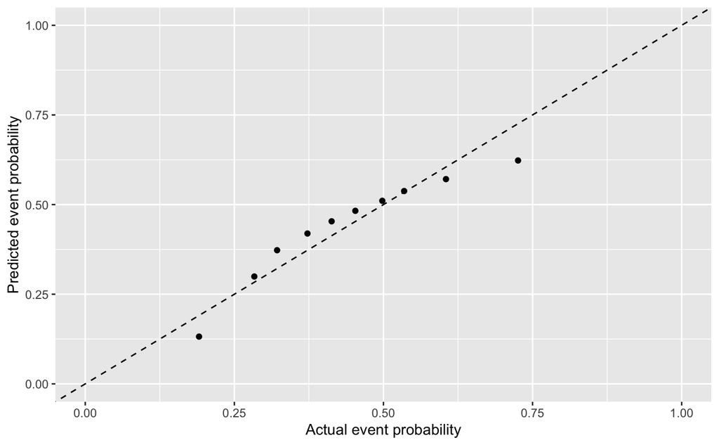

```r
# calibration plot: how well do estimated vs actual event probabilities relate to each other?
# -------------------------------------------------
actual_vs_predicted_glm<- data.frame(
  actual = ifelse(data_holdout[["home_win_flag"]] == "yes", 1, 0),
  predicted = predicted_glm2_holdout
)

# order observations accordingly

num_groups <- 10

calibration_logit <- actual_vs_predicted_glm %>%
  # ntile: assign group ids based on a variable. similar to "cut".
  mutate(predicted_score_group = ntile(predicted, num_groups)) %>%
  group_by(predicted_score_group) %>%
  summarise(mean_actual = mean(actual), mean_predicted = mean(predicted), num_obs = n())

ggplot(calibration_logit,aes(x = mean_actual, y = mean_predicted)) +
  geom_point() +
  geom_abline(intercept = 0, slope = 1, linetype = "dashed") +
  labs(x = "Actual event probability", y = "Predicted event probability") +
  ylim(0, 1) + xlim(0, 1)
```

```r
# the Brier score: MSE applied to classification evaluation

brier <- RMSE(actual_vs_predicted_glm[["predicted"]], actual_vs_predicted_glm[["actual"]])^2
message(paste0("Brier score: ", round(brier, digits = 4)))
```

```
Brier score: 0.2255
```

Ez nem jól kalibrált.

4. CALIBRATION TEST - Logistic Regression v4

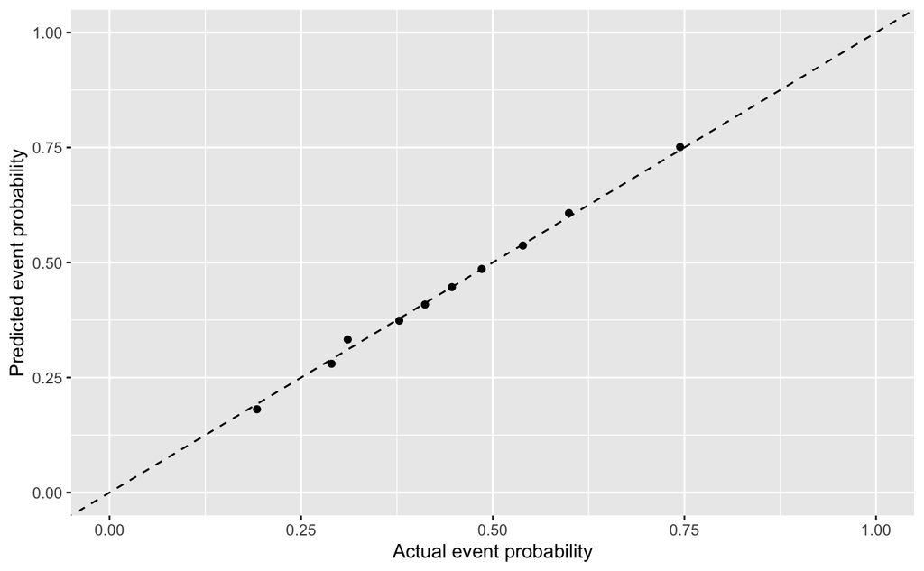

```r
# calibration plot: how well do estimated vs actual event probabilities relate to each other?
# -------------------------------------------------
actual_vs_predicted_glm<- data.frame(
  actual = ifelse(data_holdout[["home_win_flag"]] == "yes", 1, 0),
  predicted = predicted_glm4_holdout
)

# order observations accordingly

num_groups <- 10

calibration_logit <- actual_vs_predicted_glm %>%
  # ntile: assign group ids based on a variable. similar to "cut".
  mutate(predicted_score_group = ntile(predicted, num_groups)) %>%
  group_by(predicted_score_group) %>%
  summarise(mean_actual = mean(actual), mean_predicted = mean(predicted), num_obs = n())

ggplot(calibration_logit,aes(x = mean_actual, y = mean_predicted)) +
  geom_point() +
  geom_abline(intercept = 0, slope = 1, linetype = "dashed") +
  labs(x = "Actual event probability", y = "Predicted event probability") +
  ylim(0, 1) + xlim(0, 1)
```

```r
# the Brier score: MSE applied to classification evaluation

brier <- RMSE(actual_vs_predicted_glm[["predicted"]], actual_vs_predicted_glm[["actual"]])^2
message(paste0("Brier score: ", round(brier, digits = 4)))
```

```
Brier score: 0.2219
```

Cool!

5. CALIBRATION TEST - Logistic Regression v5

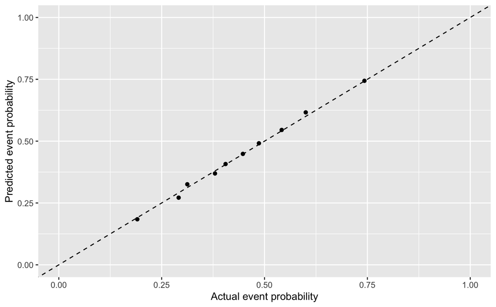

```r
# calibration plot: how well do estimated vs actual event probabilities relate to each other?
# -------------------------------------------------
actual_vs_predicted_glm<- data.frame(
  actual = ifelse(data_holdout[["home_win_flag"]] == "yes", 1, 0),
  predicted = predicted_glm5_holdout
)

# order observations accordingly

num_groups <- 10

calibration_logit <- actual_vs_predicted_glm %>%
  # ntile: assign group ids based on a variable. similar to "cut".
  mutate(predicted_score_group = ntile(predicted, num_groups)) %>%
  group_by(predicted_score_group) %>%
  summarise(mean_actual = mean(actual), mean_predicted = mean(predicted), num_obs = n())

ggplot(calibration_logit,aes(x = mean_actual, y = mean_predicted)) +
  geom_point() +
  geom_abline(intercept = 0, slope = 1, linetype = "dashed") +
  labs(x = "Actual event probability", y = "Predicted event probability") +
  ylim(0, 1) + xlim(0, 1)
```

```r
# the Brier score: MSE applied to classification evaluation

brier <- RMSE(actual_vs_predicted_glm[["predicted"]], actual_vs_predicted_glm[["actual"]])^2
message(paste0("Brier score: ", round(brier, digits = 4)))
```

```
Brier score: 0.222
```

Cool.

6. CALIBRATION TEST - Logistic Regression v6

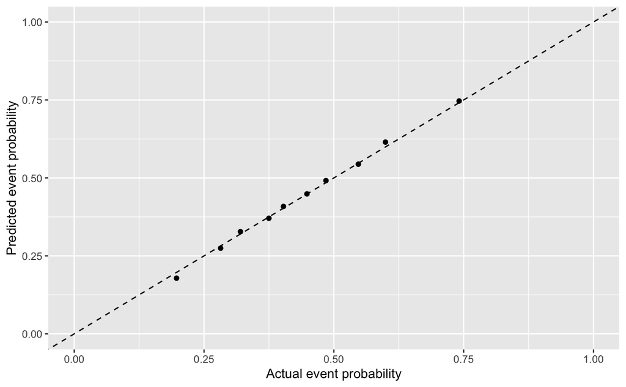

```r
# calibration plot: how well do estimated vs actual event probabilities relate to each other?
# -------------------------------------------------
actual_vs_predicted_glm<- data.frame(
  actual = ifelse(data_holdout[["home_win_flag"]] == "yes", 1, 0),
  predicted = predicted_glm6_holdout
)

# order observations accordingly

num_groups <- 10

calibration_logit <- actual_vs_predicted_glm %>%
  # ntile: assign group ids based on a variable. similar to "cut".
  mutate(predicted_score_group = ntile(predicted, num_groups)) %>%
  group_by(predicted_score_group) %>%
  summarise(mean_actual = mean(actual), mean_predicted = mean(predicted), num_obs = n())

ggplot(calibration_logit,aes(x = mean_actual, y = mean_predicted)) +
  geom_point() +
  geom_abline(intercept = 0, slope = 1, linetype = "dashed") +
  labs(x = "Actual event probability", y = "Predicted event probability") +
  ylim(0, 1) + xlim(0, 1)
```

```r
# the Brier score: MSE applied to classification evaluation

brier <- RMSE(actual_vs_predicted_glm[["predicted"]], actual_vs_predicted_glm[["actual"]])^2
message(paste0("Brier score: ", round(brier, digits = 4)))
```

```
Brier score: 0.2222
```

Cool.

7. CALIBRATION TEST - Logistic Regression v7

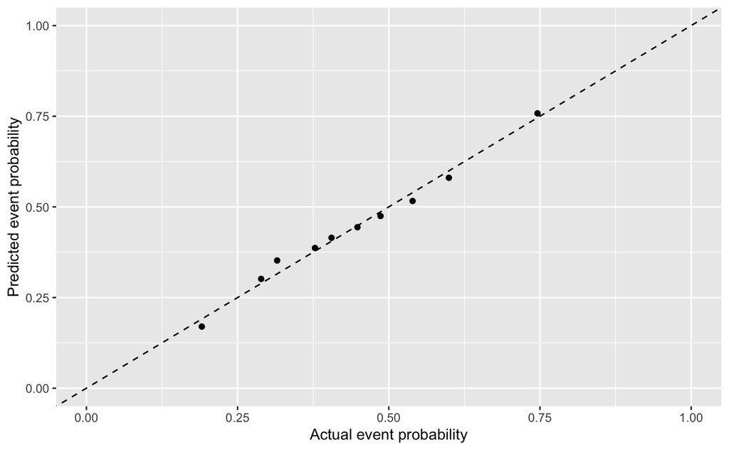

```r
# calibration plot: how well do estimated vs actual event probabilities relate to each other?
# -------------------------------------------------
actual_vs_predicted_glm<- data.frame(
  actual = ifelse(data_holdout[["home_win_flag"]] == "yes", 1, 0),
  predicted = predicted_glm7_holdout
)

# order observations accordingly

num_groups <- 10

calibration_logit <- actual_vs_predicted_glm %>%
  # ntile: assign group ids based on a variable. similar to "cut".
  mutate(predicted_score_group = ntile(predicted, num_groups)) %>%
  group_by(predicted_score_group) %>%
  summarise(mean_actual = mean(actual), mean_predicted = mean(predicted), num_obs = n())

ggplot(calibration_logit,aes(x = mean_actual, y = mean_predicted)) +
  geom_point() +
  geom_abline(intercept = 0, slope = 1, linetype = "dashed") +
  labs(x = "Actual event probability", y = "Predicted event probability") +
  ylim(0, 1) + xlim(0, 1)
```

```r
# the Brier score: MSE applied to classification evaluation

brier <- RMSE(actual_vs_predicted_glm[["predicted"]], actual_vs_predicted_glm[["actual"]])^2
message(paste0("Brier score: ", round(brier, digits = 4)))
```

```
Brier score: 0.2223
```

Good.